# Loan data from Lending Club

Panayiota Ismini Harken Alexiou

2022-12-29

# Summary

In this report we obtain Loan data from Lending Club (https://www.openintro.org/data/index.php?data=loans_full_schema) and we create a model which predicts the interest rate of the loan using logistic regression. Although the model is not accurate and it is important to improve the cleaning of the data in order to ensure the accuracy and reliability of the analysis.

## Description of Data

Below we can see the names and the explanation of the 55 variables as are described in https://www.openintro.org/data/index.php?data=loans_full_schema .

| Variable | Explanation |
| --- | --- |
| emp_title | The job title of the borrower |
| emp_length | The length of time the borrower has been employed |
| state | The borrower’s state |
| homeownership | The ownership status of the borrower’s residence |
| annual_income | The borrower’s annual income |
| verified_income | Type of verification of the borrower’s income |
| debt_to_income | The borrower’s debt-to-income ratio |
| annual_income_joint | If this is a joint application, then the annual income of the two parties applying |
| verification_income_joint | Type of verification of the joint income |
| debt_to_income_joint | Debt-to-income ratio for the two parties |
| delinq_2y | Delinquencies on lines of credit in the last 2 years |
| months_since_last_delinq | Months since the last delinquency |
| earliest_credit_line | Year of the borrower’s earliest line of credit |
| inquiries_last_12m | Inquiries into the borrower’s credit during the last 12 months |
| total_credit_lines | Total number of credit lines in the borrower’s credit history |
| open_credit_lines | Number of currently open lines of credit |
| total_credit_limit | Total available credit, e.g. if only credit cards, then the total of all the credit limits. This excludes a mortgage |
| total_credit_utilized | Total credit balance, excluding a mortgage |
| num_collections_last_12m | Number of collections in the last 12 months. This excludes medical collections |
| num_historical_failed_to_pay | The number of derogatory public records, which roughly means the number of times the applicant failed to pay |
| months_since_90d_late | Months since the last time the applicant was 90 days late on a payment |
| current_accounts_delinq | Number of accounts where the applicant is currently delinquent |
| total_collection_amount_ever | The total amount that the applicant has had against them in collections |
| current_installment_accounts | Number of installment accounts, which are (roughly) accounts with a fixed payment amount and period. A typical example might be a 36-month car loan |
| accounts_opened_24m | Number of new lines of credit opened in the last 24 months |
| months_since_last_credit_inquiry | Number of months since the last credit inquiry on this applicant |
| num_satisfactory_accounts | Number of satisfactory accounts |
| num_accounts_120d_past_due | Number of current accounts that are 120 days past due |
| num_accounts_30d_past_due | Number of current accounts that are 30 days past due |
| num_active_debit_accounts | Number of currently active bank cards |
| total_debit_limit | Total of all bank card limits |
| num_total_cc_accounts | Total number of credit card accounts in the applicant’s history |
| num_open_cc_accounts | Total number of currently open credit card accounts |
| num_cc_carrying_balance | Number of credit cards that are carrying a balance |
| num_mort_accounts | Number of mortgage accounts |
| account_never_delinq_percent | Percent of all lines of credit where the applicant was never delinquent |
| tax_liens | a numeric vector |
| public_record_bankrupt | Number of bankruptcies listed in the public record for this applicant |
| loan_purpose | The category for the purpose of the loan |
| application_type | The type of application: either individual or joint |
| loan_amount | The amount of the loan the applicant received |
| term | The number of months of the loan the applicant received |
| interest_rate | Interest rate of the loan the applicant received |
| installment | Monthly payment for the loan the applicant received |
| grade | Grade associated with the loan |
| sub_grade | Detailed grade associated with the loan |
| issue_month | Month the loan was issued |
| loan_status | Status of the loan |
| initial_listing_status | Initial listing status of the loan. (I think this has to do with whether the lender provided the entire loan or if the loan is across multiple lenders.) |
| disbursement_method | Dispersement method of the loan |
| balance | Current balance on the loan |
| paid_total | Total that has been paid on the loan by the applicant |
| paid_principal | The difference between the original loan amount and the current balance on the loan |
| paid_interest | The amount of interest paid so far by the applicant |
| paid_late_fees | Late fees paid by the applicant |

### Explore data

First, we investigate the data

```r
data=read.csv("loans_full_schema.csv")
dim(data)
```

```
## [1] 10000    55
```

We have a dataset with 55 variablels (columns) and 10000 observations (lines) then we investigate for nan and null values in each column.

```r
library(readr)
library(dplyr)

data <- read_csv("loans_full_schema.csv", col_names = TRUE)

print(paste("samples before preprocessing: ", nrow(data)))
```

```
## [1] "samples before preprocessing:  10000"
```

```r
print(paste("number of features:", ncol(data)))
```

```
## [1] "number of features: 55"
```

```r
# explore every feature - count values and nan count
for (col in colnames(data)) {
  print(col)
  print(paste("nan values ", sum(is.na(data[, col]))))
  print(paste("number of unique values: ", length(unique(data[, col]))))
  print(paste("null values: ", sum(is.na(data[, col]))))
}
```

```
## [1] "emp_title"
## [1] "nan values  833"
## [1] "number of unique values:  1"
## [1] "null values:  833"
## [1] "emp_length"
## [1] "nan values  817"
## [1] "number of unique values:  1"
## [1] "null values:  817"
## [1] "state"
## [1] "nan values  0"
## [1] "number of unique values:  1"
## [1] "null values:  0"
## [1] "homeownership"
## [1] "nan values  0"
## [1] "number of unique values:  1"
```

[output cut: 205 more lines]

The exploration of the data showed that the following variables contain null values.

| Variable | No of null/nan values |
| --- | --- |
| emp_title | 833 |
| emp_length | 817 |
| debt_to_income | 24 |
| annual_income_joint | 8505 |
| verification_income_joint | 8545 |
| debt_to_income_joint | 8505 |
| months_since_last_delinq | 5658 |
| months_since_last_credit_inquiry | 1271 |
| months_since_90d_late | 7715 |
| num_accounts_120d_past_due | 318 |

Following, we will examine the data types of the variables to determine whether they are numeric, categorical, or alphanumeric.

```r
col_names <- colnames(data)
col_types <- sapply(data, class)

for (i in 1:length(col_names)) {
  print(paste(col_names[i], ":", col_types[i]))
}
```

```
## [1] "emp_title : character"
## [1] "emp_length : numeric"
## [1] "state : character"
## [1] "homeownership : character"
## [1] "annual_income : numeric"
## [1] "verified_income : character"
## [1] "debt_to_income : numeric"
## [1] "annual_income_joint : numeric"
## [1] "verification_income_joint : character"
## [1] "debt_to_income_joint : numeric"
## [1] "delinq_2y : numeric"
## [1] "months_since_last_delinq : numeric"
## [1] "earliest_credit_line : numeric"
## [1] "inquiries_last_12m : numeric"
## [1] "total_credit_lines : numeric"
```

[output cut: 40 more lines]

We will eliminate the 833 null values of the *emp_title* variable by removing the rows with null values as we don’t have enough information about the job of the borrower.

The *verification_income_joint* is a character variable that express the type of verification of the joint income but using the *application_type* we can determine if the application is individual or joint. If the application type is individual we replace the null value with the corresponding value of *verified_income*.

```r
for (i in 1:10000){
  if (data[i,"application_type"] == "individual"){
    data[i,"verification_income_joint"]=data[i,"verified_income"]
  }
}
sum(is.na(data[,9]))
```

```
## [1] 40
```

As a result, we have 40 Null values of *verification_income_joint* that we will remove them.

Regarding the numeric variables with Null values

- *emp_length*
- *debt_to_income*
- *annual_income_joint*
- *debt_to_income_joint*
- *months_since_last_delinq*
- *months_since_90d_late*
- *num_accounts_120d_past_due*
- *months_since_last_credit_inquiry*

we will describe the steps were carried out in order to eliminate the Null values for each variable.  
At first, we visualize the *emp_length* and consider its distribution. The histogram shows that the data are left-skewed so in this case we replace the null values with the mean value.

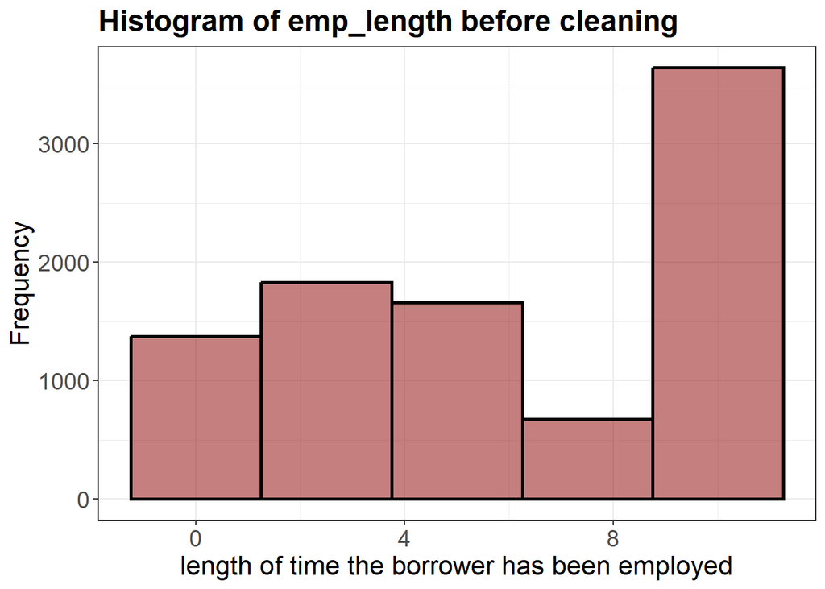

```r
library(ggplot2)
library(tidyr)
ggplot(data=data.frame(data$emp_length), aes(data$emp_length))+ geom_histogram(bins=5,fill = "darkred",
                 alpha = 0.5,
                 color = "black",
                 size = 1) +
  labs(title = "Histogram of emp_length before cleaning",
       x = "length of time the borrower has been employed",
       y = "Frequency") +
  theme_bw() +
  theme(plot.title = element_text(size = 18,
                                  face = "bold"),
        axis.title = element_text(size = 16),
        axis.text = element_text(size = 14))
```

```r
mean_emp_length= mean(data$emp_length, na.rm=TRUE)
mean_emp_length
```

```
## [1] 5.930306
```

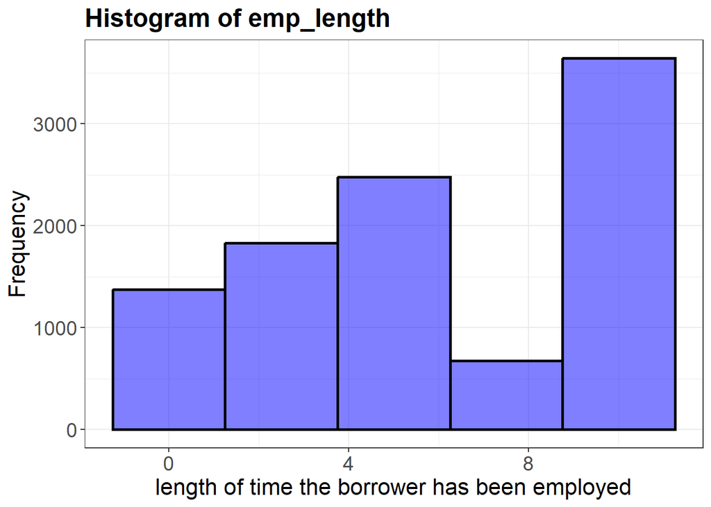

```r
for (i in 1:10000){
  if (is.na(data[i,"emp_length"])){
    data[i,"emp_length"]=mean_emp_length
  }
}

ggplot(data=data.frame(data$emp_length), aes(data$emp_length))+ geom_histogram(bins=5,fill = "blue",
                 alpha = 0.5,
                 color = "black",
                 size = 1) +
  labs(title = "Histogram of emp_length",
       x = "length of time the borrower has been employed",
       y = "Frequency") +
  theme_bw() +
  theme(plot.title = element_text(size = 18,
                                  face = "bold"),
        axis.title = element_text(size = 16),
        axis.text = element_text(size = 14))
```

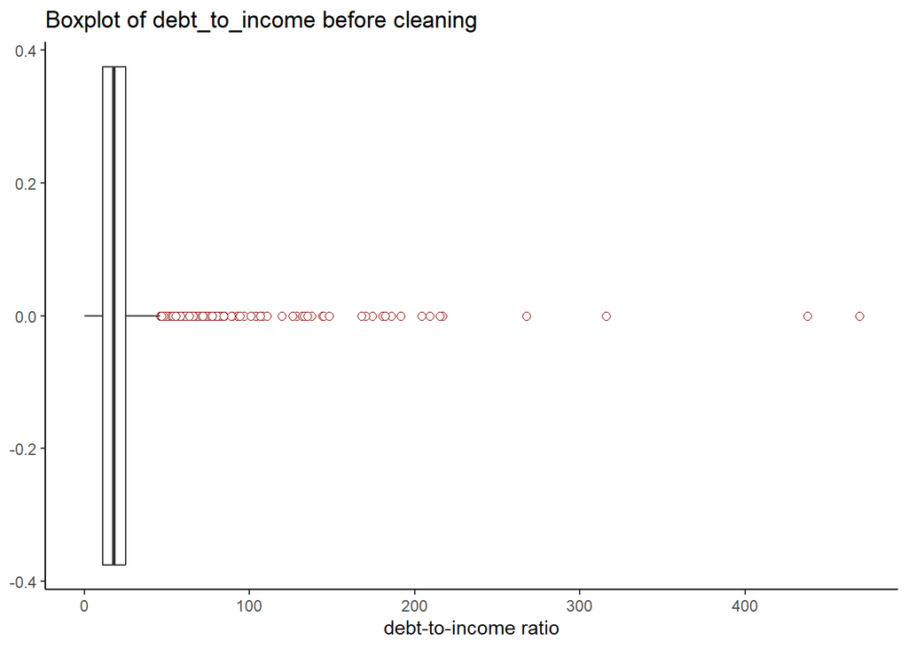

```r
ggplot(data=data.frame(data$debt_to_income), aes(data$debt_to_income))+ geom_boxplot(outlier.colour = "darkred",
                 outlier.shape =  21,
                 outlier.size = 2) +
  labs(title = "Boxplot of debt_to_income before cleaning",
       x = "debt-to-income ratio") +
  theme_classic()
```

```r
debt_to_income_median= median(data$debt_to_income, na.rm=TRUE)
debt_to_income_median
```

```
## [1] 17.57
```

```r
for (i in 1:10000){
  if (is.na(data$debt_to_income[i])){
    data[i,"debt_to_income"]=debt_to_income_median
  }
}
```

The *annual_income_joint* is a variable that express the annual income of the two parties applying. By *application_type* we can determine if the application is individual or joint. If the application type is individual we replace the Null value with the corresponding value of *annual_income*. As a result, there is no null value in the column *annual_income_joint*.

```r
for (i in 1:10000){
  if (data[i,"application_type"] == "individual"){
    data[i,"annual_income_joint"]=data[i,"annual_income"]
  }
}
sum(is.na(data$annual_income_joint))
```

```
## [1] 0
```

The *debt_to_income_joint* is a variable that express the debt-to-income ratio of the joint income. By *application_type* we can determine if the application is individual or joint. If the application type is individual we replace the Null value with the corresponding value of *debt_to_income*. As a result, there is no null value in the column *annual_income_joint*.

```r
for (i in 1:10000){
  if (data[i,"application_type"] == "individual"){
    data$debt_to_income_joint[i]=data$debt_to_income[i]
  }
}
sum(is.na(data$debt_to_income_joint))
```

```
## [1] 0
```

We plot a histogram of the variable *months_since_last_delinq* to visualize the distribution of its values. The histogram shows that the values are skewed to the right with a peak at around 35 months. As a result, we replace the NAs with the median value.

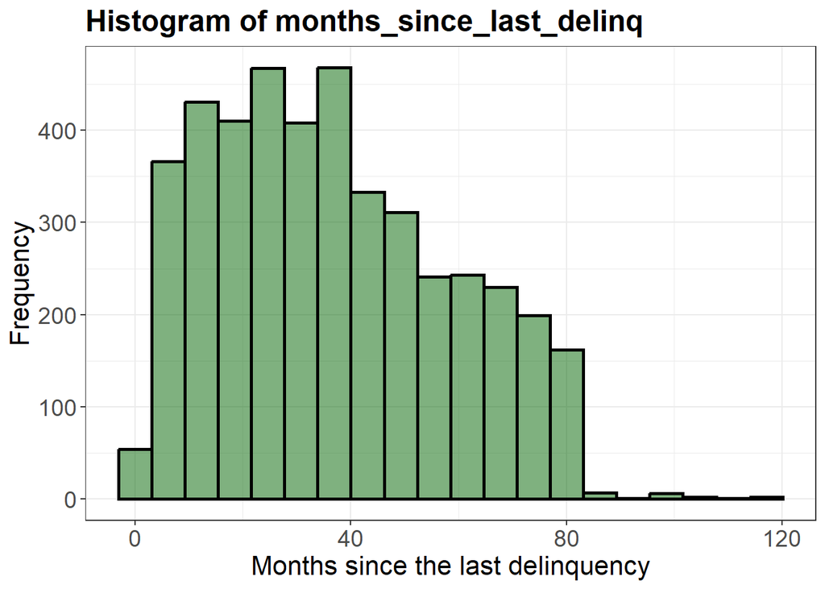

```r
ggplot(data=data.frame(data$months_since_last_delinq), aes(data$months_since_last_delinq))+ geom_histogram(bins=20,fill = "darkgreen",
                 alpha = 0.5,
                 color = "black",
                 size = 1) +
  labs(title = "Histogram of months_since_last_delinq",
       x = "Months since the last delinquency",
       y = "Frequency") +
  theme_bw() +
  theme(plot.title = element_text(size = 18,
                                  face = "bold"),
        axis.title = element_text(size = 16),
        axis.text = element_text(size = 14))
```

```r
median_months_since_last_delinq= median(data$months_since_last_delinq, na.rm=TRUE)
median_months_since_last_delinq
```

```
## [1] 34
```

```r
for (i in 1:10000){
  if (is.na(data[i,"months_since_last_delinq"])){
    data[i,"months_since_last_delinq"]=median_months_since_last_delinq
  }
}
```

Next, to understand the distribution of values for *months_since_90d_late*, we create a histogram. The plot shows that the distribution of the variable is approximately normal so we replace the Null values with the mean of the non-null values for that variable.

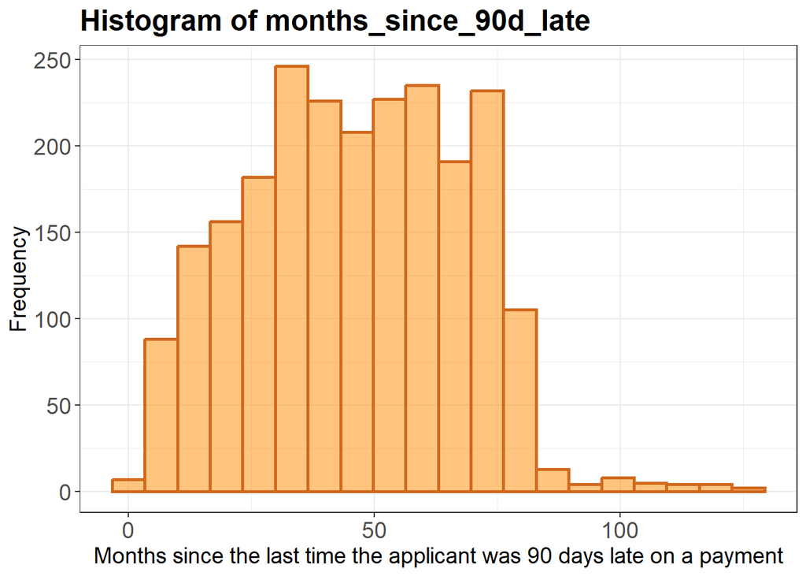

```r
ggplot(data=data.frame(data$months_since_90d_late), aes(data$months_since_90d_late))+ geom_histogram(bins=20,fill = "darkorange",
                 alpha = 0.5,
                 color = "chocolate",
                 size = 1) +
  labs(title = "Histogram of months_since_90d_late",
       x = "Months since the last time the applicant was 90 days late on a payment",
       y = "Frequency") +
  theme_bw() +
  theme(plot.title = element_text(size = 18,
                                  face = "bold"),
        axis.title = element_text(size = 14),
        axis.text = element_text(size = 14))
```

```r
mean_months_since_90d_late= mean(data$months_since_90d_late, na.rm=TRUE)
mean_months_since_90d_late
```

```
## [1] 46.11247
```

```r
for (i in 1:10000){
  if (is.na(data[i,"months_since_90d_late"])){
    data[i,"months_since_90d_late"]=round(mean_months_since_90d_late)
  }
}
```

Following, we create the boxplot of the *num_accounts_120d_past_due*. The plot shows that the all the values of the data set are 0. So we replace the null values with 0.

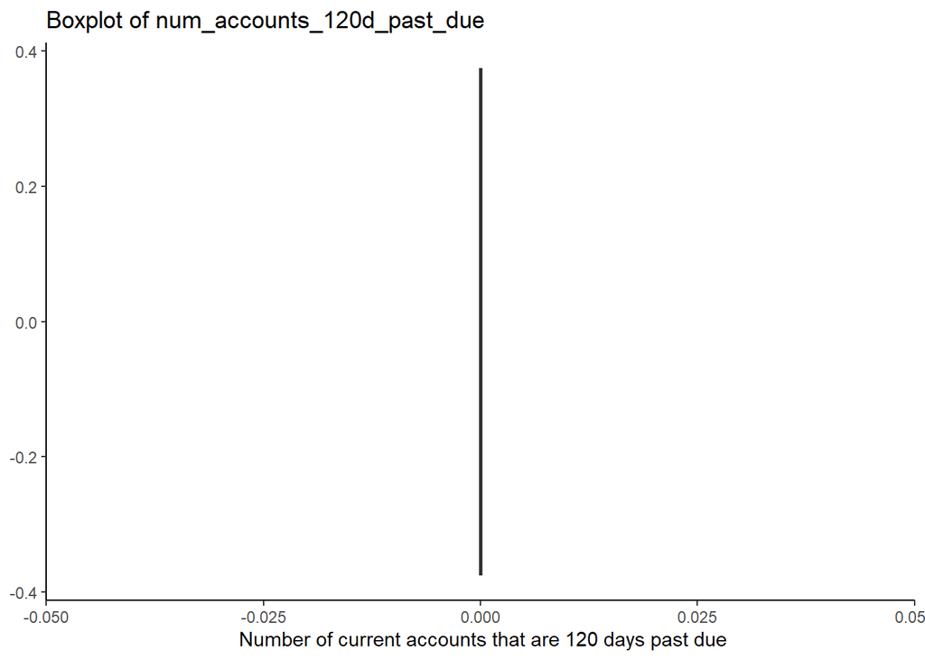

```r
ggplot(data=data.frame(data$num_accounts_120d_past_due), aes(data$num_accounts_120d_past_due))+ geom_boxplot(outlier.colour = "deeppink3",
                 outlier.shape =  21,
                 outlier.size = 2) +
  labs(title = "Boxplot of num_accounts_120d_past_due",
       x = " Number of current accounts that are 120 days past due") +
  theme_classic()
```

```r
for (i in 1:10000){
  if (is.na(data$num_accounts_120d_past_due[i])){
    data$num_accounts_120d_past_due[i]=0
  }
}
```

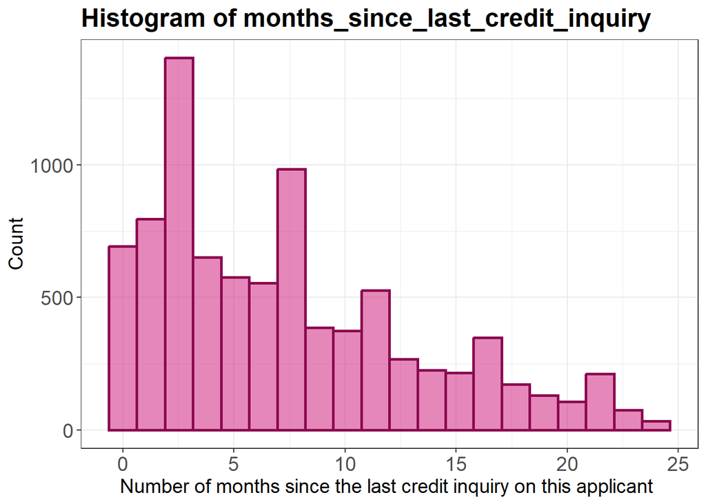

```r
ggplot(data=data.frame(data$months_since_last_credit_inquiry), aes(data$months_since_last_credit_inquiry))+ geom_histogram(bins=20,fill = "deeppink3",
                 alpha = 0.5,
                 color = "deeppink4",
                 size = 1) +
  labs(title = "Histogram of months_since_last_credit_inquiry",
       x = "Number of months since the last credit inquiry on this applicant ",
       y = "Count") +
  theme_bw() +
  theme(plot.title = element_text(size = 18,
                                  face = "bold"),
        axis.title = element_text(size = 14),
        axis.text = element_text(size = 14))
```

```r
median_months_since_last_inquiry= median(data$months_since_last_credit_inquiry, na.rm=TRUE)
median_months_since_last_inquiry
```

```
## [1] 6
```

```r
for (i in 1:10000){
  if (is.na(data[i,"months_since_last_credit_inquiry"])){
    data[i,"months_since_last_credit_inquiry"]=round(median_months_since_last_inquiry)
  }
}
```

Finally, we remove the observations with Null value and the final dataset has 9133 observations and 55 features.

```r
data=na.omit(data)
print(paste("data after without Null values:", nrow(data)))
```

```
## [1] "data after without Null values: 9133"
```

```r
print(paste("number of features:", ncol(data)))
```

```
## [1] "number of features: 55"
```

## Visualization of the data

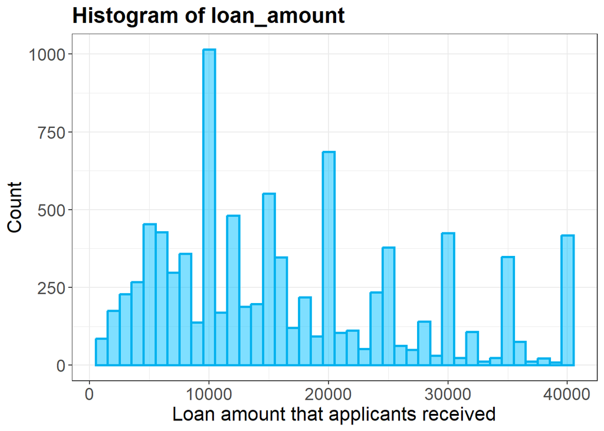

```r
ggplot(data=data.frame(data$loan_amount), aes(data$loan_amount))+ geom_histogram(bins=40,fill = "deepskyblue",
                 alpha = 0.5,
                 color = "deepskyblue2",
                 size = 1) +
  labs(title = "Histogram of loan_amount",
       x = "Loan amount that applicants received",
       y = "Count") +
  theme_bw() +
  theme(plot.title = element_text(size = 18,
                                  face = "bold"),
        axis.title = element_text(size = 16),
        axis.text = element_text(size = 14))
```

Following, we investigate the purposes that applicants took a loan. The majority of the applicants (51.4%) obtain a loan to pay off their dept and the 22.7% obtain a loan to pay off their credit card.

```
## ------------------------------------------------------------------------------
## Loan purposes
##
##   length      n    NAs unique levels  dupes
##    9'133  9'133      0     12     12      y
##          100.0%   0.0%
##
##                  level   freq   perc  cumfreq  cumperc
## 1   debt_consolidation  4'694  51.4%    4'694    51.4%
## 2          credit_card  2'070  22.7%    6'764    74.1%
## 3                other    818   9.0%    7'582    83.0%
## 4     home_improvement    625   6.8%    8'207    89.9%
## 5       major_purchase    282   3.1%    8'489    92.9%
## 6                house    140   1.5%    8'629    94.5%
## 7              medical    136   1.5%    8'765    96.0%
## 8       small_business    121   1.3%    8'886    97.3%
## 9                  car    114   1.2%    9'000    98.5%
## 10              moving     68   0.7%    9'068    99.3%
## 11            vacation     55   0.6%    9'123    99.9%
## 12    renewable_energy     10   0.1%    9'133   100.0%
```

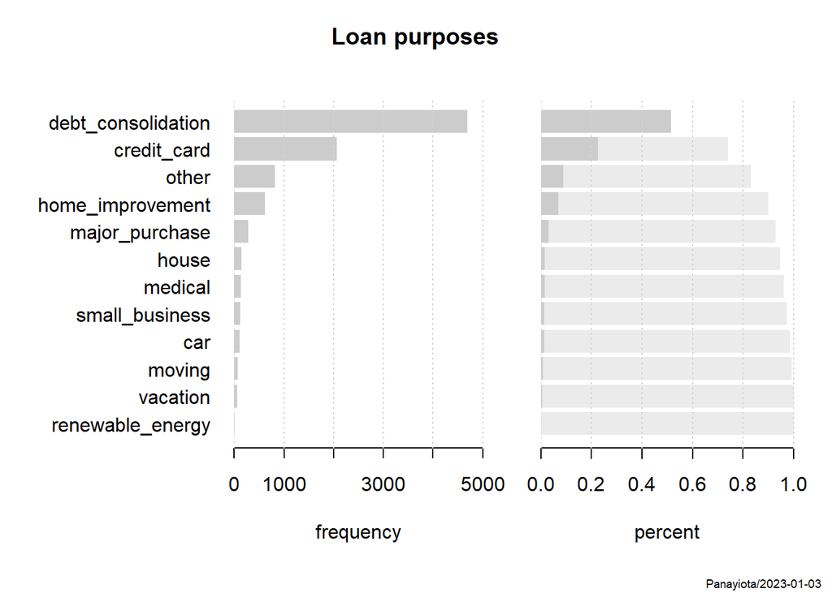

```r
library(DescTools)
Desc(data$loan_purpose, main = "Loan purposes", plotit = TRUE)
```

After that, we will investigate the states of USA that have the highest and the lowest distributions of loan amounts. It is shown that states of ILINOIS, ARIZONA, MINNESOTA, OHAIO and IDAHO have the highest amounts of loans while states of PENNSYLVANIA, VEMRONT and SOUTH DAKOTA have the lowest loan amounts.

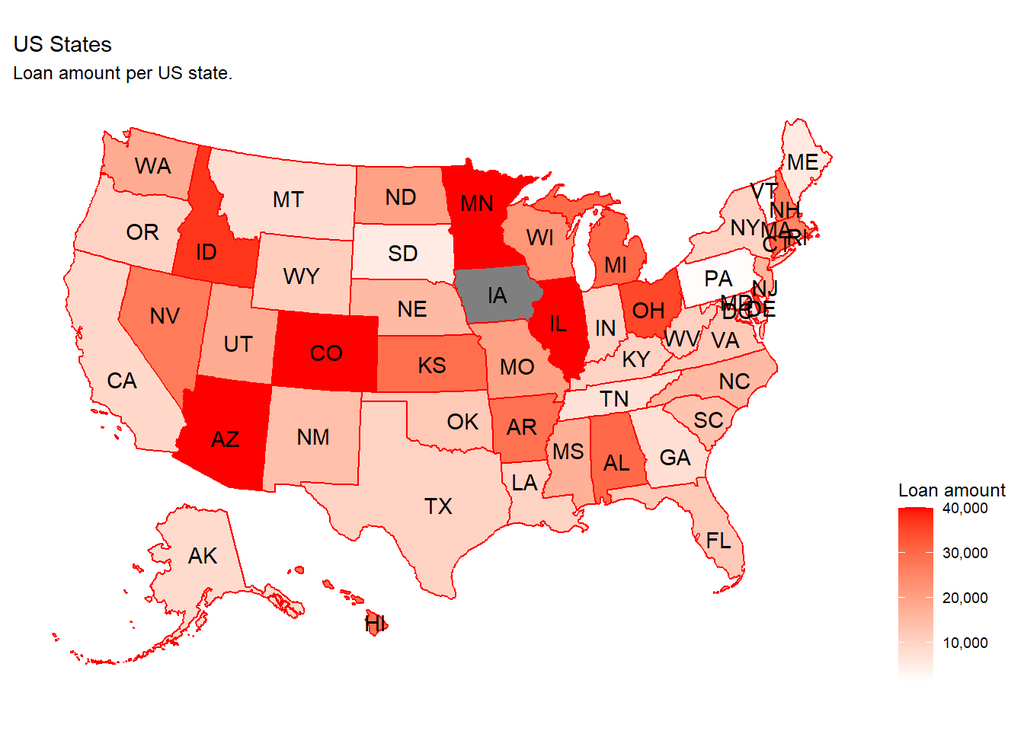

```r
library(usmap)
values=data$loan_amount
state=data$state
plot_usmap(data=data.frame(state, values), color="red", labels=TRUE)  + scale_fill_continuous( low = "white", high = "red", name = "Loan amount", label = scales::comma) + labs(title = "US States", subtitle = "Loan amount per US state.") + theme(legend.position = "right")
```

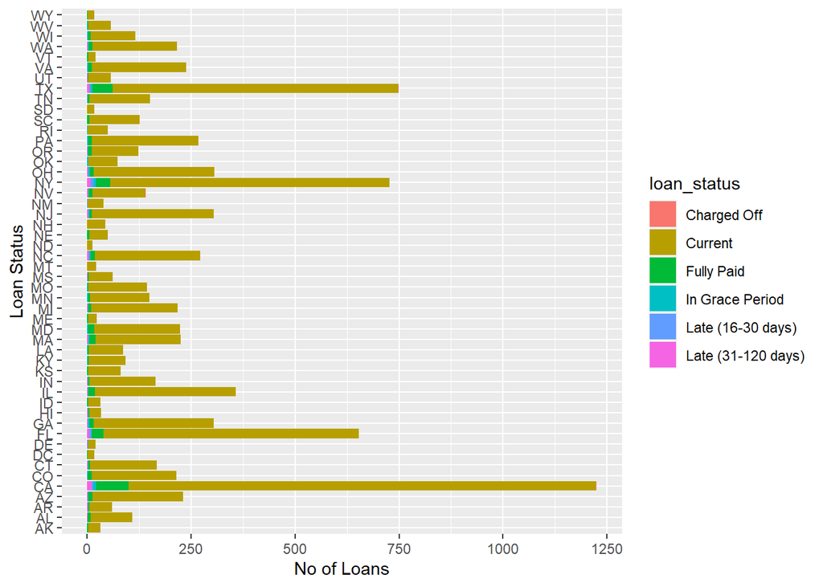

```r
ggplot(data, aes(x=state,fill=loan_status))+
  labs(x="Loan Status", y="No of Loans")+
  geom_bar() +
  coord_flip()
```

In the following plot, it is shown that the majority of applicants with dept to income ratio between (0,35) applied for a loan of no more than $20,000 and the majority of these loans have current status. Also the majority of fully paid loans are in this range. It is obvious that the highest loan amounts have status current.

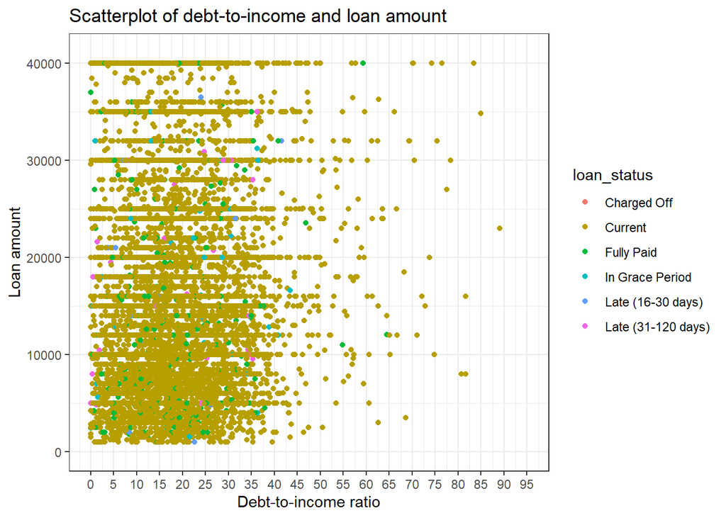

```r
my.colors <- RColorBrewer::brewer.pal(n = 6,name = "Paired")
names(my.colors) <- levels(as.factor(data$loan_status))
plt <- ggplot(data, aes(debt_to_income, loan_amount, color = loan_status)) + geom_point()+
  labs(x = "Debt-to-income ratio", y = "Loan amount", title = "Scatterplot of debt-to-income and loan amount") +
  scale_x_continuous(limits = c(0, 95), breaks = seq(0, 95, 5)) +
  scale_y_continuous(limits = c(0, 41000), breaks = seq(0, 41000, 10000)) +
  theme_bw() +
  theme(legend.position = "right")
plt
```

## Build of models

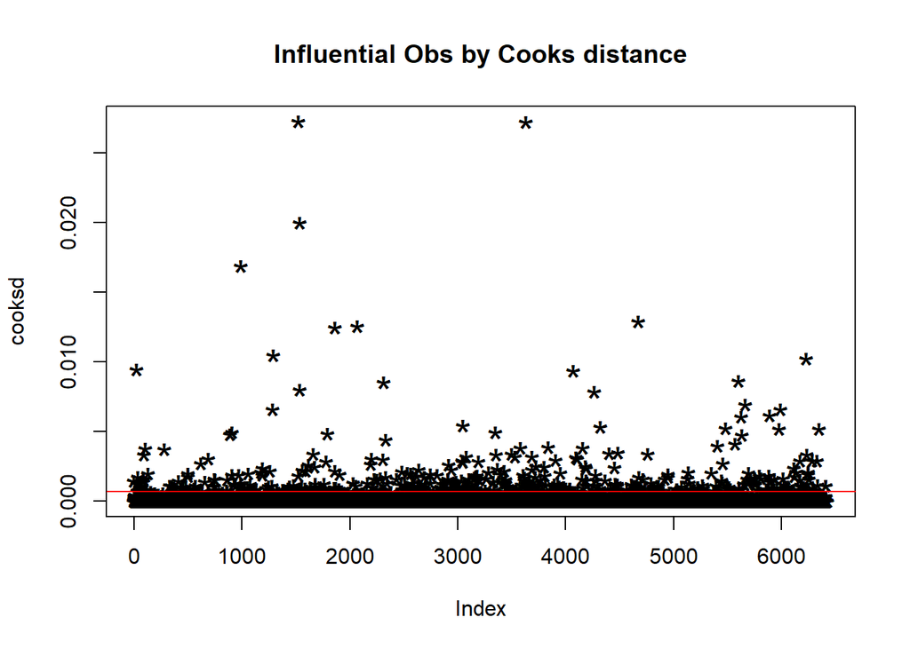

```r
int_rate=c()
for (i in 1:nrow(data)){
  if (data$interest_rate[i]<15 | data$interest_rate[i]==15 ){
    int_rate[i]="low"}
  else{
    int_rate[i]="high"

  }
}
int_rate=factor(int_rate)

data$int_rate=int_rate


library(knitr)
library(tidyverse)
library(ggplot2)
library(mice)
library(lattice)
library(reshape2)
library(DataExplorer)

library(caTools)


data1=data

data1$state=(factor(data1$state))
data1$verified_income=(factor(data1$verified_income))
data1$verification_income_joint=(factor(data1$verification_income_joint))
data1$application_type=(factor(data1$application_type))
data1$issue_month=(factor(data1$issue_month))
data1$loan_purpose=(factor(data1$loan_purpose))
data1$disbursement_method=(factor(data1$disbursement_method))
data1$grade=(factor(data1$grade))
data1$sub_grade=(factor(data1$sub_grade))
data1$loan_status=(factor(data1$loan_status))
data1$homeownership=(factor(data1$homeownership))
data1$initial_listing_status=factor((data1$initial_listing_status))

data1=as.data.frame(data1)
library(dplyr)
data1= select(data1, -emp_title, -interest_rate,-state,-sub_grade,-num_accounts_120d_past_due,-num_accounts_30d_past_due,-public_record_bankrupt)
set.seed(1234)
ind <- sample(2, nrow(data1), replace = T, prob = c(0.7, 0.3))
train <- data1[ind == 1,]
test <- data1[ind == 2,]

cooksd <- cooks.distance(glm(int_rate ~ ., family = "binomial", data = train))

plot(cooksd,pch="*",  cex=2, main="Influential Obs by Cooks distance")
abline(h = 4*mean(cooksd, na.rm=T), col="red")
```

```r
outliers <- rownames(train[cooksd > 4*mean(cooksd, na.rm=T), ])
train=train[!(row.names(train) %in% outliers),]
```

```r
model <- glm(int_rate ~ ., family = "binomial", train)
summary(model)
```

```
##
## Call:
## glm(formula = int_rate ~ ., family = "binomial", data = train)
##
## Deviance Residuals:
##    Min      1Q  Median      3Q     Max
## -3.195   0.000   0.000   0.000   2.510
##
## Coefficients:
##                                            Estimate Std. Error z value Pr(>|z|)
## (Intercept)                              -1.192e+01  3.437e+04   0.000  0.99972
## emp_length                               -1.901e-02  2.628e-02  -0.723  0.46946
## homeownershipOWN                          2.137e-01  3.444e-01   0.621  0.53487
## homeownershipRENT                        -3.201e-01  2.599e-01  -1.231  0.21815
## annual_income                            -1.601e-06  1.506e-05  -0.106  0.91531
## verified_incomeSource Verified           -3.116e-01  1.028e+00  -0.303  0.76181
## verified_incomeVerified                   1.937e+01  2.702e+04   0.001  0.99943
## debt_to_income                            1.066e-02  3.220e-02   0.331  0.74054
## annual_income_joint                       7.372e-06  1.470e-05   0.501  0.61603
## verification_income_jointSource Verified  3.965e-02  1.029e+00   0.039  0.96925
## verification_income_jointVerified        -2.010e+01  2.702e+04  -0.001  0.99941
## debt_to_income_joint                     -2.778e-03  3.462e-02  -0.080  0.93603
## delinq_2y                                 1.090e-01  2.205e-01   0.494  0.62100
## months_since_last_delinq                 -9.367e-03  8.730e-03  -1.073  0.28333
## earliest_credit_line                      3.024e-02  1.553e-02   1.947  0.05151
## inquiries_last_12m                       -1.391e-01  4.640e-02  -2.998  0.00272
## total_credit_lines                       -3.868e-02  2.039e-02  -1.897  0.05780
## open_credit_lines                         2.501e+00  1.760e+00   1.421  0.15518
## total_credit_limit                        1.698e-06  1.329e-06   1.278  0.20125
## total_credit_utilized                    -1.883e-06  3.420e-06  -0.551  0.58190
## num_collections_last_12m                 -2.379e+00  1.766e+00  -1.347  0.17803
## num_historical_failed_to_pay             -2.290e-01  2.843e-01  -0.806  0.42047
## months_since_90d_late                     1.160e-02  1.153e-02   1.006  0.31450
## current_accounts_delinq                  -2.617e+01  1.310e+05   0.000  0.99984
## total_collection_amount_ever              3.221e-04  1.566e-04   2.056  0.03976
## current_installment_accounts              4.094e-01  2.150e-01   1.904  0.05691
## accounts_opened_24m                      -6.748e-02  3.897e-02  -1.732  0.08330
## months_since_last_credit_inquiry          4.005e-02  1.875e-02   2.136  0.03268
## num_satisfactory_accounts                -2.838e+00  1.780e+00  -1.595  0.11080
## num_active_debit_accounts                 8.675e-02  9.092e-02   0.954  0.34003
```

[output cut: 110 more lines]

```
## balance
## paid_total
## paid_principal
## paid_interest
## paid_late_fees
## ---
## Signif. codes:  0 '***' 0.001 '**' 0.01 '*' 0.05 '.' 0.1 ' ' 1
##
## (Dispersion parameter for binomial family taken to be 1)
##
##     Null deviance: 6909.70  on 6033  degrees of freedom
## Residual deviance:  805.11  on 5962  degrees of freedom
## AIC: 949.11
##
## Number of Fisher Scoring iterations: 23
```

```r
backwards= step(model, direction="backward",trace=0 )
summary(backwards)
```

```
##
## Call:
## glm(formula = int_rate ~ annual_income_joint + verification_income_joint +
##     earliest_credit_line + inquiries_last_12m + total_credit_lines +
##     open_credit_lines + total_credit_limit + num_collections_last_12m +
##     total_collection_amount_ever + current_installment_accounts +
##     accounts_opened_24m + months_since_last_credit_inquiry +
##     num_satisfactory_accounts + num_active_debit_accounts + num_total_cc_accounts +
##     num_open_cc_accounts + num_cc_carrying_balance + num_mort_accounts +
##     account_never_delinq_percent + loan_purpose + term + installment +
##     grade + issue_month + loan_status + initial_listing_status +
##     disbursement_method + balance + paid_total + paid_interest,
##     family = "binomial", data = train)
##
## Deviance Residuals:
##    Min      1Q  Median      3Q     Max
## -3.204   0.000   0.000   0.000   2.618
##
## Coefficients:
##                                            Estimate Std. Error z value Pr(>|z|)
## (Intercept)                              -1.058e+01  3.436e+03  -0.003  0.99754
## annual_income_joint                       5.357e-06  2.895e-06   1.851  0.06419
## verification_income_jointSource Verified -2.652e-01  2.099e-01  -1.263  0.20646
## verification_income_jointVerified        -7.149e-01  2.641e-01  -2.707  0.00679
## earliest_credit_line                      3.180e-02  1.467e-02   2.167  0.03024
## inquiries_last_12m                       -1.384e-01  4.595e-02  -3.013  0.00259
## total_credit_lines                       -3.767e-02  1.911e-02  -1.971  0.04872
## open_credit_lines                         1.477e+00  1.118e+00   1.321  0.18649
## total_credit_limit                        2.077e-06  1.151e-06   1.804  0.07122
## num_collections_last_12m                 -2.340e+00  1.741e+00  -1.344  0.17893
## total_collection_amount_ever              2.734e-04  1.468e-04   1.863  0.06250
## current_installment_accounts              3.331e-01  2.039e-01   1.634  0.10227
## accounts_opened_24m                      -7.420e-02  3.795e-02  -1.955  0.05057
## months_since_last_credit_inquiry          4.126e-02  1.830e-02   2.255  0.02412
## num_satisfactory_accounts                -1.749e+00  1.111e+00  -1.574  0.11545
## num_active_debit_accounts                 1.364e-01  7.613e-02   1.791  0.07327
## num_total_cc_accounts                     5.785e-02  3.417e-02   1.693  0.09049
## num_open_cc_accounts                      3.131e-01  2.091e-01   1.497  0.13431
## num_cc_carrying_balance                  -1.361e-01  6.705e-02  -2.030  0.04238
## num_mort_accounts                         3.200e-01  9.430e-02   3.394  0.00069
```

[output cut: 80 more lines]

```
## initial_listing_statuswhole              .
## disbursement_methodDirectPay             **
## balance                                  ***
## paid_total                               ***
## paid_interest                            ***
## ---
## Signif. codes:  0 '***' 0.001 '**' 0.01 '*' 0.05 '.' 0.1 ' ' 1
##
## (Dispersion parameter for binomial family taken to be 1)
##
##     Null deviance: 6909.70  on 6033  degrees of freedom
## Residual deviance:  820.29  on 5982  degrees of freedom
## AIC: 924.29
##
## Number of Fisher Scoring iterations: 22
```

```r
## to predict using logistic regression model, probablilities obtained

log.predictions <- predict(model, test, type="response")

## Look at probability output
head(log.predictions, 10)
```

```
##            5           14           16           26           28           29
## 8.220063e-01 2.220446e-16 2.220446e-16 1.000000e+00 1.000000e+00 2.220446e-16
##           36           39           40           50
## 6.235733e-01 5.676145e-01 9.999779e-01 1.000000e+00
```

```r
log.predictions2 <- predict(backwards, test, type="response")

## Look at probability output
head(log.predictions, 10)
```

```
##            5           14           16           26           28           29
## 8.220063e-01 2.220446e-16 2.220446e-16 1.000000e+00 1.000000e+00 2.220446e-16
##           36           39           40           50
## 6.235733e-01 5.676145e-01 9.999779e-01 1.000000e+00
```

```r
log.prediction.rd <- ifelse(log.predictions > 0.5, 1, 0)
head(log.prediction.rd, 10)
```

```
##  5 14 16 26 28 29 36 39 40 50
##  1  0  0  1  1  0  1  1  1  1
```

```r
table(log.prediction.rd, test[,18])
```

```
##
## log.prediction.rd    0    1    2    3    4    5   52
##                 0  587  114    4    2    0    1    1
##                 1 1762  210   21    3    2    1    0
```

```r
accuracy <- table(log.prediction.rd, test[,18])
sum(diag(accuracy))/sum(accuracy)
```

```
## [1] 0.2943131
```

```r
head(log.predictions2, 10)
```

```
##            5           14           16           26           28           29
## 8.082319e-01 2.220446e-16 2.220446e-16 1.000000e+00 1.000000e+00 2.220446e-16
##           36           39           40           50
## 5.844667e-01 5.700564e-01 9.999756e-01 1.000000e+00
```

```r
log.prediction.rd2 <- ifelse(log.predictions2 > 0.5, 1, 0)
head(log.prediction.rd2, 10)
```

```
##  5 14 16 26 28 29 36 39 40 50
##  1  0  0  1  1  0  1  1  1  1
```

```r
table(log.prediction.rd2, test[,18])
```

```
##
## log.prediction.rd2    0    1    2    3    4    5   52
##                  0  588  113    6    2    0    1    1
##                  1 1761  211   19    3    2    1    0
```

```r
accuracy2 <- table(log.prediction.rd2, test[,18])
sum(diag(accuracy2))/sum(accuracy2)
```

```
## [1] 0.2950517
```

As a result, we need to build a better model. It is necessary to improve the cleaning of the data in order to ensure the accuracy and reliability of the analysis. This may involve handling missing values, scaling numeric variables and correcting the skewness in data and encoding categorical variables. Additionally, it may be beneficial to perform feature selection to select the most relevant variables for the model.

Unfortunately, the results of this project did not meet the desired standards. If given more time, I would have implemented additional changes in order to improve the results. I sincerely apologize for any inconvenience this may have caused.